# Txi Cab Drivers through Payment Type Analysis

# Problem Statement

##### In the fast-paced taxi booking sector, making the most of revenue is essential for long-term success and driver happiness. Our goal is to use data-driven insights to maximise revenue streams for taxi drivers in order to meet this need. Our research aimsto determine whether payment methods have an impact on fare pricing by focusing on the 2relationship between payment type and fare amount.

# Objective

# Research Question

##### Is there a relationship between total fare amount and payment type and can we nudge customers towards payment methods that generate higher revenue for drivers, without negatively impacting customer experience?

# Importing Libraries

```python
import pandas as pd
import numpy as nm
import matplotlib.pyplot as plt
import seaborn as sns
import scipy.stats as st
import warnings
import statsmodels.api as sm
warnings.filterwarnings('ignore')
```

# Loading the dataset

```python
df = pd.read_csv('yellow_tripdata_2020-01.csv')
df.head()
```

|  | VendorID | tpep_pickup_datetime | tpep_dropoff_datetime | passenger_count | trip_distance | RatecodeID | store_and_fwd_flag | PULocationID | DOLocationID | payment_type | fare_amount | extra | mta_tax | tip_amount | tolls_amount | improvement_surcharge | total_amount | congestion_surcharge |
| --- | --- | --- | --- | --- | --- | --- | --- | --- | --- | --- | --- | --- | --- | --- | --- | --- | --- | --- |
| 0 | 1.0 | 2020-01-01 00:28:15 | 2020-01-01 00:33:03 | 1.0 | 1.2 | 1.0 | N | 238 | 239 | 1.0 | 6.0 | 3.0 | 0.5 | 1.47 | 0.0 | 0.3 | 11.27 | 2.5 |
| 1 | 1.0 | 2020-01-01 00:35:39 | 2020-01-01 00:43:04 | 1.0 | 1.2 | 1.0 | N | 239 | 238 | 1.0 | 7.0 | 3.0 | 0.5 | 1.50 | 0.0 | 0.3 | 12.30 | 2.5 |
| 2 | 1.0 | 2020-01-01 00:47:41 | 2020-01-01 00:53:52 | 1.0 | 0.6 | 1.0 | N | 238 | 238 | 1.0 | 6.0 | 3.0 | 0.5 | 1.00 | 0.0 | 0.3 | 10.80 | 2.5 |
| 3 | 1.0 | 2020-01-01 00:55:23 | 2020-01-01 01:00:14 | 1.0 | 0.8 | 1.0 | N | 238 | 151 | 1.0 | 5.5 | 0.5 | 0.5 | 1.36 | 0.0 | 0.3 | 8.16 | 0.0 |
| 4 | 2.0 | 2020-01-01 00:01:58 | 2020-01-01 00:04:16 | 1.0 | 0.0 | 1.0 | N | 193 | 193 | 2.0 | 3.5 | 0.5 | 0.5 | 0.00 | 0.0 | 0.3 | 4.80 | 0.0 |

```python
df.shape
```

```
(6405008, 18)
```

```python
df.dtypes
```

```
VendorID                 float64
tpep_pickup_datetime      object
tpep_dropoff_datetime     object
passenger_count          float64
trip_distance            float64
RatecodeID               float64
store_and_fwd_flag        object
PULocationID               int64
DOLocationID               int64
payment_type             float64
fare_amount              float64
extra                    float64
mta_tax                  float64
tip_amount               float64
tolls_amount             float64
improvement_surcharge    float64
total_amount             float64
congestion_surcharge     float64
dtype: object
```

##### There are so ,any columns in the dataset, but as per our problem statement, we only require some fieds from the original data. Rest columns are nothing but the unwanted columns for this study, So we will simply remove those columns.

```python
df = df[['passenger_count','payment_type','fare_amount','trip_distance']]
```

```python
df
```

|  | passenger_count | payment_type | fare_amount | trip_distance |
| --- | --- | --- | --- | --- |
| 0 | 1.0 | 1.0 | 6.00 | 1.20 |
| 1 | 1.0 | 1.0 | 7.00 | 1.20 |
| 2 | 1.0 | 1.0 | 6.00 | 0.60 |
| 3 | 1.0 | 1.0 | 5.50 | 0.80 |
| 4 | 1.0 | 2.0 | 3.50 | 0.00 |
| ... | ... | ... | ... | ... |
| 6405003 | NaN | NaN | 17.59 | 3.24 |
| 6405004 | NaN | NaN | 46.67 | 22.13 |
| 6405005 | NaN | NaN | 48.85 | 10.51 |
| 6405006 | NaN | NaN | 27.17 | 5.49 |
| 6405007 | NaN | NaN | 54.56 | 11.60 |

6405008 rows × 4 columns

# Missing value

```python
df.isnull().sum()
```

```
passenger_count    65441
payment_type       65441
fare_amount            0
trip_distance          0
dtype: int64
```

```python
(65441/len(df))*100
```

```
1.021716132126611
```

```python
df.dropna(inplace = True)
```

```python
df
```

|  | passenger_count | payment_type | fare_amount | trip_distance |
| --- | --- | --- | --- | --- |
| 0 | 1.0 | 1.0 | 6.0 | 1.20 |
| 1 | 1.0 | 1.0 | 7.0 | 1.20 |
| 2 | 1.0 | 1.0 | 6.0 | 0.60 |
| 3 | 1.0 | 1.0 | 5.5 | 0.80 |
| 4 | 1.0 | 2.0 | 3.5 | 0.00 |
| ... | ... | ... | ... | ... |
| 6339562 | 1.0 | 1.0 | 11.0 | 2.10 |
| 6339563 | 1.0 | 1.0 | 13.0 | 2.13 |
| 6339564 | 1.0 | 1.0 | 12.5 | 2.55 |
| 6339565 | 1.0 | 2.0 | 8.5 | 1.61 |
| 6339566 | 1.0 | 1.0 | 0.0 | 0.00 |

6339567 rows × 4 columns

```python
df.drop_duplicates(inplace = True)
```

```python
df['passenger_count'].value_counts(normalize = True)
```

```
passenger_count
1.0    0.388762
2.0    0.205883
3.0    0.112218
5.0    0.105831
6.0    0.081783
4.0    0.079212
0.0    0.026149
7.0    0.000075
8.0    0.000044
9.0    0.000044
Name: proportion, dtype: float64
```

```python
df['payment_type'].value_counts(normalize = True)
```

```
payment_type
1.0    0.566971
2.0    0.382117
3.0    0.026440
4.0    0.024468
5.0    0.000003
Name: proportion, dtype: float64
```

##### We will focus solely on payment types 'Card' and 'Cash', denoted by 1 and 2 in the dataset. To ensure our analysis centers on these payment methods, we'll fiter the data accordingly, excluding all other types.

```python
df = df[df['payment_type']<3]
df = df[(df['passenger_count'] >0)&(df['passenger_count']<6)]
```

```python
df.shape
```

```
(269500, 4)
```

```python
df['payment_type'].replace([1,2],["Card","Cash"],inplace = True)
```

```python
df.describe()
```

|  | passenger_count | fare_amount | trip_distance |
| --- | --- | --- | --- |
| count | 269500.000000 | 269500.000000 | 269500.000000 |
| mean | 2.254905 | 32.653422 | 8.737979 |
| std | 1.402785 | 26.980174 | 7.326103 |
| min | 1.000000 | -500.000000 | -22.180000 |
| 25% | 1.000000 | 16.500000 | 3.190000 |
| 50% | 2.000000 | 27.000000 | 7.010000 |
| 75% | 3.000000 | 44.000000 | 12.580000 |
| max | 5.000000 | 4265.000000 | 262.880000 |

##### Furthermore, observing the maximum and 50th percentile values, it's possible that data contains significant outliers, particularly high values. These outliers need to be addressed and removed to ensure the integrity of the analysis.

```python
df = df[df['fare_amount']>0]
df = df[df['trip_distance']>0]
```

```python
for col in ['fare_amount','trip_distance',]:
    q1 = df[col].quantile(0.25)
    q3 = df[col].quantile(0.75)
    IQR = q3-q1

    lower_bound = q1-1.5*IQR
    upper_bound = q3+1.5*IQR

    df = df[(df[col]>=lower_bound) & (df[col]<=upper_bound)]
```

##### We interested on exploing the relationship netween pyment type and passenger behavior concerning trip distance and fare amount. Are there variations on the distribution of payment types concerning different fare amounts or trip distances?

# Bars plots

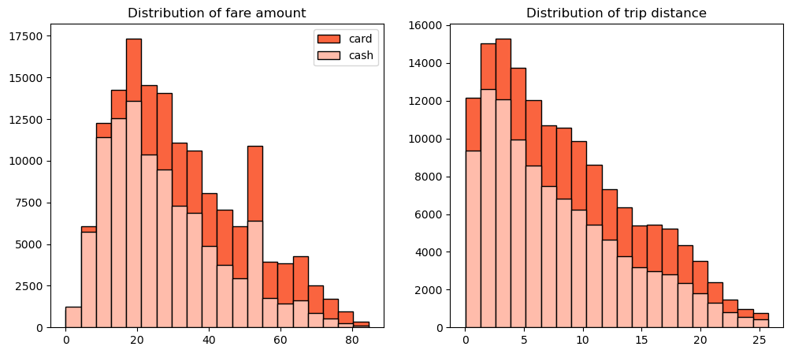

```python
plt.figure(figsize=(12,5))
plt.subplot(1,2,1)
plt.title('Distribution of fare amount')
plt.hist(df[df['payment_type']=='Card']['fare_amount'], histtype= 'barstacked', bins = 20, edgecolor = 'k', color = '#FA643F', label = 'card')
plt.hist(df[df['payment_type']=='Cash']['fare_amount'], histtype= 'barstacked', bins = 20, edgecolor = 'k', color = '#FFBCAB', label = 'cash')
plt.legend()

plt.subplot(1,2,2)
plt.title('Distribution of trip distance')
plt.hist(df[df['payment_type']=='Card']['trip_distance'], histtype= 'barstacked', bins = 20, edgecolor = 'k', color = '#FA643F', label = 'card')
plt.hist(df[df['payment_type']=='Cash']['trip_distance'], histtype= 'barstacked', bins = 20, edgecolor = 'k', color = '#FFBCAB', label = 'cash')
plt.show()
```

# Pie Charts

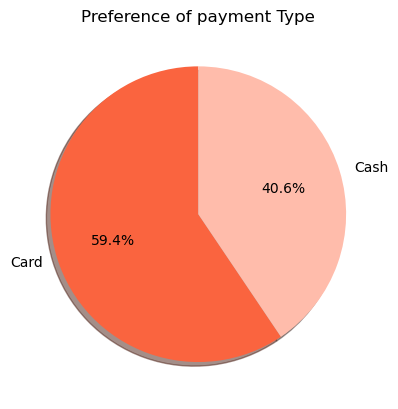

```python
plt.title('Preference of payment Type')
plt.pie(df['payment_type'].value_counts(normalize = True), labels = df['payment_type'].value_counts().index,
       startangle = 90,shadow = True, autopct = '%1.1f%%', colors = ['#FA643F','#FFBCAB'])
plt.show()
```

##### Subsequently, we aim to conduct an analysis of the payment type in relation to the passenger count Our objective is to investigate if there are any changes in preference contingent upon the number of passenger traveing in the cab.

##### To facistate this examination, we have employed a visualization technique known as a stacked bar plot. This method is particularly advantageous for comparing the percentage distribution of each passenger count bassed on the payment method selected. Through this graphical representation, we can gain insights into potential variations in payment preferences across different passenger counts.

# Passenger Count Analysis

```python
passenger_count = df.groupby(['payment_type','passenger_count'])[['passenger_count']].count()
passenger_count.rename(columns = {'passenger_count':'count'}, inplace = True)
passenger_count.reset_index(inplace = True)
```

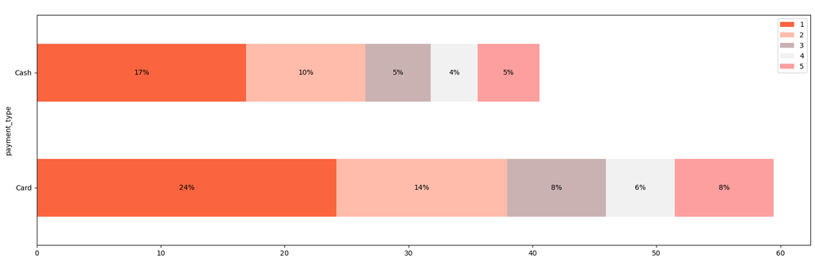

```python
passenger_count = df.groupby(['payment_type','passenger_count'])[['passenger_count']].count()

passenger_count.rename(columns = {'passenger_count':'count'},inplace = True)
passenger_count.reset_index(inplace = True)

passenger_count['perc'] = (passenger_count['count']/passenger_count['count'].sum())*100

df = pd.DataFrame(columns = ['payment_type',1,2,3,4,5])
df['payment_type'] = ['Card','Cash']
df.iloc[0,1:] = passenger_count.iloc[:5,-1]
df.iloc[1,1:] = passenger_count.iloc[5:,-1]


fig, ax = plt.subplots(figsize=(20, 6))
df.plot(x='payment_type', kind='barh', stacked=True, title=' ', ax=ax, color = ['#FA643F', '#FFBCAB', '#CBB2B2', '#F1F1F1', '#FD9F9F'])

# Add percentage text
for p in ax.patches:
    width = p.get_width()
    height = p.get_height()
    x, y = p.get_xy()
    ax.text(x + width / 2,
            y + height / 2,
            '{:.0f}%'.format(width),
            horizontalalignment='center',
            verticalalignment='center')
```

# Training and Testing to apply ML Alogrithm

```python
X=df.drop('payment_type',axis=1)
y = df['payment_type']
```

```python
from sklearn.model_selection import train_test_split
```

```python
X_train, X_test, y_train, y_test = train_test_split(X, y, test_size=0.2, random_state=51)
#test_size = 0.2 it means we use 20 % of dataset for test purpose where 80% for train purpose
print('Shape of X_train = ', X_train.shape)
print('Shape of y_train = ', y_train.shape)
print('Shape of X_test = ', X_test.shape)
print('Shape of y_test = ', y_test.shape)
```

[output not shown]

```python
from sklearn.preprocessing import StandardScaler
from sklearn.preprocessing import MinMaxScaler
```

```python
sc = StandardScaler()
sc.fit(df)
```

[output not shown]

# MinMaxScaler

```python
mmc = MinMaxScaler()
mmc.fit(df)
```

[output not shown]

```python
df_mmc = mmc.transform(df)
df_mmc
```

[output not shown]

```python
df_mmc = pd.DataFrame(df_mmc,columns = ['trip_distance','payment_type'])
```

```python
df_mmc
```

[output not shown]